# Project 3 - CNN & Pre-trained Model Comparison

### Aleks Kamenev

Steps

1. Imports
2. Load in data
3. As we are working with prepared data only some demo visualization is needed for project
4. CNN custom model (either from project guide or inspired by the code provided their)
5. Visualization and some graph for custom CNN
6. Pre-trained model
7. Visualization for pre-trained and graphs
8. Def

### 1. Imports

```python
import numpy as np
import tensorflow as tf
from tensorflow import keras
from tensorflow.keras import layers
from tensorflow.keras import Model
from tensorflow.keras.models import Sequential
from tensorflow.keras.layers import Activation, Dense, Flatten, BatchNormalization, Conv2D, MaxPool2D
from tensorflow.keras.optimizers import Adam
from tensorflow.keras.metrics import categorical_crossentropy
from tensorflow.keras.preprocessing.image import ImageDataGenerator
from sklearn.metrics import confusion_matrix
import itertools
import os
import shutil
import random
import glob
import matplotlib.pyplot as plt
import warnings
warnings.simplefilter(action='ignore', category=FutureWarning)
%matplotlib inline
```

```python
# import pre-trained model
from tensorflow.keras.applications.inception_v3 import InceptionV3

from tensorflow.keras.applications.vgg16 import VGG16
```

```python
# for load model
from tensorflow.keras.models import load_model
```

```python
from tensorflow.keras.preprocessing.image import ImageDataGenerator
```

```python
from tensorflow.keras.optimizers import RMSprop
```

```python
from tensorflow.keras.preprocessing.image import ImageDataGenerator
```

```python
# Check for GPU
physical_devices = tf.config.experimental.list_physical_devices('GPU')
print("Num GPUs Available: ", len(physical_devices))
tf.config.experimental.set_memory_growth(physical_devices[0], True)
```

```
Num GPUs Available:  1
```

### 2. Load in data

```python
# Pre Process as is in the guide
```

```python
base_dir = r'C:\Fall_2021\Deep_Learning_671\Project_3\data'
```

```python
train_dir = os.path.join(base_dir, 'train')
validation_dir = os.path.join(base_dir, 'validation')
test_dir = os.path.join(base_dir, 'test')
```

```python
print("train_dir path is : ", train_dir)
print(" ")
print("validation_dir path is : ", validation_dir)
print(" ")
print("validation_dir path is : ", test_dir)
```

```
train_dir path is :  C:\Fall_2021\Deep_Learning_671\Project_3\data\train

validation_dir path is :  C:\Fall_2021\Deep_Learning_671\Project_3\data\validation

validation_dir path is :  C:\Fall_2021\Deep_Learning_671\Project_3\data\test
```

```python
train_cats_dir = os.path.join(train_dir, 'cats') # Directory with our training cat pictures
train_dogs_dir = os.path.join(train_dir, 'dogs') # Directory with our training dog pictures
```

```python
print("train_cats_dir path is : ", train_cats_dir)
print(" ")
print("train_dogs_dir path is : ", train_dogs_dir)
```

```
train_cats_dir path is :  C:\Fall_2021\Deep_Learning_671\Project_3\data\train\cats

train_dogs_dir path is :  C:\Fall_2021\Deep_Learning_671\Project_3\data\train\dogs
```

```python
validation_cats_dir = os.path.join(validation_dir, 'cats') # Directory with our validation cat pictures
validation_dogs_dir = os.path.join(validation_dir, 'dogs')# Directory with our validation dog pictures
```

```python
print("validation_cats_dir path is : ", validation_cats_dir)
print(" ")
print("validation_dogs_dir path is : ", validation_dogs_dir)
```

```
validation_cats_dir path is :  C:\Fall_2021\Deep_Learning_671\Project_3\data\validation\cats

validation_dogs_dir path is :  C:\Fall_2021\Deep_Learning_671\Project_3\data\validation\dogs
```

```python
test_cats_dir = os.path.join(validation_dir, 'cats') # Directory with our test cat pictures
test_dogs_dir = os.path.join(validation_dir, 'dogs')# Directory with our test dog pictures
```

```python
print("test_cats_dir path is : ", test_cats_dir)
print(" ")
print("test_dogs_dir path is : ", test_dogs_dir)
```

```
test_cats_dir path is :  C:\Fall_2021\Deep_Learning_671\Project_3\data\validation\cats

test_dogs_dir path is :  C:\Fall_2021\Deep_Learning_671\Project_3\data\validation\dogs
```

```python
train_cat_fnames = os.listdir(train_cats_dir)
train_cat_fnames
```

[output not shown]

[output cut: 940 more lines]

[output not shown]

```python
train_dog_fnames = os.listdir(train_dogs_dir)
train_dog_fnames
```

[output not shown]

[output cut: 945 more lines]

[output not shown]

```python
train_datagen = ImageDataGenerator(rescale = 1./255.,
                                   rotation_range=60,
                                   width_shift_range = 0.2,
                                   height_shift_range = 0.2,
                                   shear_range = 0.2,
                                   zoom_range = 0.2,
                                   horizontal_flip = True,
                                  fill_mode="nearest")
```

```python
# Note that the validation data should not be augmented!
test_datagen = ImageDataGenerator( rescale = 1.0/255. )
```

```python
# Flow training images in batches of 20 using train_datagen generator
train_generator = train_datagen.flow_from_directory(train_dir,
                                                    batch_size = 20,
                                                    class_mode = 'binary',
                                                    target_size = (224, 224))
```

```
Found 2000 images belonging to 2 classes.
```

```python
# Flow validation images in batches of 20 using test_datagen generator
validation_generator =  test_datagen.flow_from_directory( validation_dir,
                                                          batch_size  = 20,
                                                          class_mode  = 'binary',
                                                          target_size = (224, 224))
```

```
Found 2000 images belonging to 2 classes.
```

```python
# After some issues with Image and some extensive google searches
```

```python
# my preprocess
```

```python
train_batches = ImageDataGenerator(preprocessing_function=tf.keras.applications.inception_v3.preprocess_input) \
    .flow_from_directory(directory=train_dir, target_size=(224,224),  class_mode = 'binary', batch_size=20)
valid_batches = ImageDataGenerator(preprocessing_function=tf.keras.applications.inception_v3.preprocess_input) \
    .flow_from_directory(directory=validation_dir, target_size=(224,224), class_mode = 'binary', batch_size=20)
test_batches = ImageDataGenerator(preprocessing_function=tf.keras.applications.inception_v3.preprocess_input) \
    .flow_from_directory(directory=test_dir, target_size=(224,224), class_mode = 'binary', batch_size=20, shuffle=False)
```

```
Found 2000 images belonging to 2 classes.
Found 2000 images belonging to 2 classes.
Found 300 images belonging to 2 classes.
```

```python
assert train_batches.n == 2000
assert valid_batches.n == 2000
assert test_batches.n == 300
assert test_batches.num_classes == valid_batches.num_classes == test_batches.num_classes == 2
```

### 3. As we are working with prepared data only some demo visualization is needed for project

```python
imgs, labels = next(train_batches)
```

[output not shown]

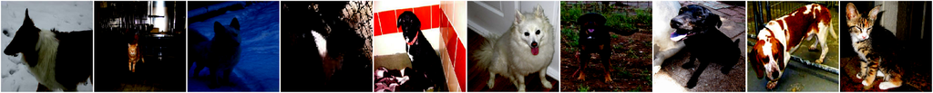

```
[1. 0. 1. 1. 1. 1. 1. 1. 1. 0. 1. 1. 1. 1. 0. 1. 1. 0. 1. 0.]
```

```python
plotImages(imgs)
print(labels)
```

### 4. CNN custom model (either from project guide or inspired by the code provided their)

```python
# Model as provided
```

```python
model_given_cnn = tf.keras.models.Sequential([
    tf.keras.layers.Conv2D(32, (3,3), activation='relu', padding ='same', input_shape=(224, 224, 3)),
    tf.keras.layers.MaxPooling2D(2, 2),
    tf.keras.layers.Conv2D(64, (3,3), activation='relu', padding ='same'),
    tf.keras.layers.MaxPooling2D(2, 2),
    tf.keras.layers.Conv2D(128, (3,3), activation='relu', padding ='same'),
    tf.keras.layers.MaxPooling2D(2, 2),
    tf.keras.layers.Conv2D(128, (3,3), activation='relu', padding ='same'),
    tf.keras.layers.MaxPooling2D(2, 2),
    tf.keras.layers.Flatten(),
    tf.keras.layers.Dense(512, activation='relu'),
    tf.keras.layers.Dense(1, activation='sigmoid')
])
```

```python
model_given_cnn.summary()
```

```
Model: "sequential_13"
_________________________________________________________________
 Layer (type)                Output Shape              Param #
=================================================================
 conv2d_494 (Conv2D)         (None, 224, 224, 32)      896

 max_pooling2d_44 (MaxPoolin  (None, 112, 112, 32)     0
 g2D)

 conv2d_495 (Conv2D)         (None, 112, 112, 64)      18496

 max_pooling2d_45 (MaxPoolin  (None, 56, 56, 64)       0
 g2D)

 conv2d_496 (Conv2D)         (None, 56, 56, 128)       73856

 max_pooling2d_46 (MaxPoolin  (None, 28, 28, 128)      0
 g2D)

 conv2d_497 (Conv2D)         (None, 28, 28, 128)       147584

 max_pooling2d_47 (MaxPoolin  (None, 14, 14, 128)      0
 g2D)

 flatten_9 (Flatten)         (None, 25088)             0

 dense_21 (Dense)            (None, 512)               12845568

 dense_22 (Dense)            (None, 1)                 513

=================================================================
Total params: 13,086,913
Trainable params: 13,086,913
Non-trainable params: 0
_________________________________________________________________
```

```python
model_given_cnn.compile(optimizer=Adam(learning_rate=0.0001), loss='binary_crossentropy', metrics = ['acc'])
```

```python
model_given_history = model_given_cnn.fit(x=train_batches, validation_data=valid_batches, epochs=20, verbose=2)
```

```
100/100 - 6s - loss: 0.4712 - acc: 0.7795 - val_loss: 0.5534 - val_acc: 0.7135 - 6s/epoch - 63ms/step
100/100 - 6s - loss: 0.4110 - acc: 0.8120 - val_loss: 0.5649 - val_acc: 0.7115 - 6s/epoch - 62ms/step
100/100 - 6s - loss: 0.3781 - acc: 0.8340 - val_loss: 0.5785 - val_acc: 0.7125 - 6s/epoch - 61ms/step
100/100 - 6s - loss: 0.3033 - acc: 0.8760 - val_loss: 0.5887 - val_acc: 0.7240 - 6s/epoch - 60ms/step
100/100 - 6s - loss: 0.2644 - acc: 0.8980 - val_loss: 0.6235 - val_acc: 0.7140 - 6s/epoch - 61ms/step
100/100 - 6s - loss: 0.2080 - acc: 0.9180 - val_loss: 0.6203 - val_acc: 0.7290 - 6s/epoch - 60ms/step
100/100 - 6s - loss: 0.1456 - acc: 0.9540 - val_loss: 0.6957 - val_acc: 0.7285 - 6s/epoch - 60ms/step
100/100 - 6s - loss: 0.1048 - acc: 0.9680 - val_loss: 0.7368 - val_acc: 0.7180 - 6s/epoch - 61ms/step
100/100 - 6s - loss: 0.0817 - acc: 0.9775 - val_loss: 0.8182 - val_acc: 0.7225 - 6s/epoch - 60ms/step
100/100 - 6s - loss: 0.0624 - acc: 0.9850 - val_loss: 0.8703 - val_acc: 0.7335 - 6s/epoch - 61ms/step
100/100 - 6s - loss: 0.0256 - acc: 0.9990 - val_loss: 1.0501 - val_acc: 0.7250 - 6s/epoch - 61ms/step
100/100 - 6s - loss: 0.0237 - acc: 0.9980 - val_loss: 1.0144 - val_acc: 0.7370 - 6s/epoch - 60ms/step
100/100 - 6s - loss: 0.0109 - acc: 1.0000 - val_loss: 1.0928 - val_acc: 0.7280 - 6s/epoch - 60ms/step
100/100 - 6s - loss: 0.0074 - acc: 1.0000 - val_loss: 1.2152 - val_acc: 0.7265 - 6s/epoch - 60ms/step
100/100 - 6s - loss: 0.0045 - acc: 1.0000 - val_loss: 1.1834 - val_acc: 0.7430 - 6s/epoch - 60ms/step
100/100 - 6s - loss: 0.0028 - acc: 1.0000 - val_loss: 1.2587 - val_acc: 0.7405 - 6s/epoch - 60ms/step
100/100 - 6s - loss: 0.0022 - acc: 1.0000 - val_loss: 1.2749 - val_acc: 0.7430 - 6s/epoch - 60ms/step
100/100 - 6s - loss: 0.0018 - acc: 1.0000 - val_loss: 1.3183 - val_acc: 0.7415 - 6s/epoch - 60ms/step
100/100 - 6s - loss: 0.0015 - acc: 1.0000 - val_loss: 1.3471 - val_acc: 0.7425 - 6s/epoch - 60ms/step
100/100 - 6s - loss: 0.0012 - acc: 1.0000 - val_loss: 1.3753 - val_acc: 0.7435 - 6s/epoch - 61ms/step
```

### 5. Visualization and some graph for custom CNN

```python
# for model_given
# serious overfitting by 7,14 epoch
```

[figure not shown]

```python
simple_plot_acc_model(model_given_history)
```

### 5.1 Predict (for fun)

[output not shown]

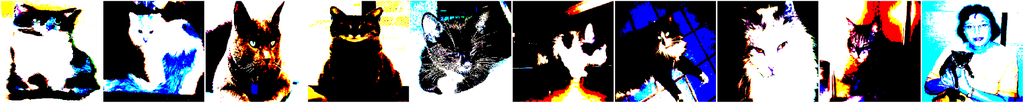

```
[0. 0. 0. 0. 0. 0. 0. 0. 0. 0. 0. 0. 0. 0. 0. 0. 0. 0. 0. 0.]
```

```python
test_images, test_labels = next(test_batches)
plotImages(test_images)
print(test_labels)
```

```python
test_batches.classes
```

```
array([0, 0, 0, 0, 0, 0, 0, 0, 0, 0, 0, 0, 0, 0, 0, 0, 0, 0, 0, 0, 0, 0,
       0, 0, 0, 0, 0, 0, 0, 0, 0, 0, 0, 0, 0, 0, 0, 0, 0, 0, 0, 0, 0, 0,
       0, 0, 0, 0, 0, 0, 0, 0, 0, 0, 0, 0, 0, 0, 0, 0, 0, 0, 0, 0, 0, 0,
       0, 0, 0, 0, 0, 0, 0, 0, 0, 0, 0, 0, 0, 0, 0, 0, 0, 0, 0, 0, 0, 0,
       0, 0, 0, 0, 0, 0, 0, 0, 0, 0, 0, 0, 0, 0, 0, 0, 0, 0, 0, 0, 0, 0,
       0, 0, 0, 0, 0, 0, 0, 0, 0, 0, 0, 0, 0, 0, 0, 0, 0, 0, 0, 0, 0, 0,
       0, 0, 0, 0, 0, 0, 0, 0, 0, 0, 0, 0, 0, 0, 0, 0, 0, 0, 1, 1, 1, 1,
       1, 1, 1, 1, 1, 1, 1, 1, 1, 1, 1, 1, 1, 1, 1, 1, 1, 1, 1, 1, 1, 1,
       1, 1, 1, 1, 1, 1, 1, 1, 1, 1, 1, 1, 1, 1, 1, 1, 1, 1, 1, 1, 1, 1,
       1, 1, 1, 1, 1, 1, 1, 1, 1, 1, 1, 1, 1, 1, 1, 1, 1, 1, 1, 1, 1, 1,
       1, 1, 1, 1, 1, 1, 1, 1, 1, 1, 1, 1, 1, 1, 1, 1, 1, 1, 1, 1, 1, 1,
       1, 1, 1, 1, 1, 1, 1, 1, 1, 1, 1, 1, 1, 1, 1, 1, 1, 1, 1, 1, 1, 1,
       1, 1, 1, 1, 1, 1, 1, 1, 1, 1, 1, 1, 1, 1, 1, 1, 1, 1, 1, 1, 1, 1,
       1, 1, 1, 1, 1, 1, 1, 1, 1, 1, 1, 1, 1, 1])
```

```python
predictions = model_given.predict(x=test_batches, verbose=0)
```

```python
np.round(predictions)
```

```
array([[0.],
       [0.],
       [0.],
       [1.],
       [0.],
       [1.],
       [0.],
       [0.],
       [0.],
       [1.],
       [1.],
       [0.],
       [0.],
       [0.],
       [0.],
       [1.],
       [0.],
       [0.],
       [1.],
       [1.],
       [0.],
       [0.],
       [0.],
       [0.],
       [0.],
       [1.],
       [0.],
       [0.],
       [1.],
       [0.],
       [0.],
       [0.],
       [1.],
       [0.],
       [0.],
       [0.],
       [0.],
       [0.],
       [0.],
       [1.],
```

[output cut: 245 more lines]

```
       [1.],
       [1.],
       [1.],
       [1.],
       [0.],
       [1.],
       [0.],
       [1.],
       [1.],
       [1.],
       [1.],
       [0.],
       [0.],
       [0.],
       [1.]], dtype=float32)
```

```python
cm = confusion_matrix(y_true=test_batches.classes, y_pred=np.round(predictions))
```

```python
test_batches.class_indices
```

```
{'cats': 0, 'dogs': 1}
```

```
Normalized confusion matrix
[[0.74666667 0.25333333]
 [0.28       0.72      ]]
```

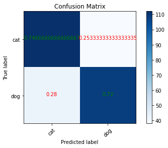

```python
cm_plot_labels = ['cat','dog']
plot_confusion_matrix(cm=cm, classes=cm_plot_labels, title='Confusion Matrix')
```

### 6. Pre-trained model

```python
# As per guide
```

```python
InceptionV3
```

```
<function keras.applications.inception_v3.InceptionV3(include_top=True, weights='imagenet', input_tensor=None, input_shape=None, pooling=None, classes=1000, classifier_activation='softmax')>
```

Reference:

- [Rethinking the Inception Architecture for Computer Vision](http://arxiv.org/abs/1512.00567) (CVPR 2016)

This function returns a Keras image classification model, optionally loaded with weights pre-trained on ImageNet.

For image classification use cases, see [this page for detailed examples](https://keras.io/api/applications/#usage-examples-for-image-classification-models).

For transfer learning use cases, make sure to read the [guide to transfer learning & fine-tuning](https://keras.io/guides/transfer_learning/).

Note: each Keras Application expects a specific kind of input preprocessing. For `InceptionV3`, call `tf.keras.applications.inception_v3.preprocess_input` on your inputs before passing them to the model. `inception_v3.preprocess_input` will scale input pixels between -1 and 1.

```
- `None` (default) means that the output of the model will be
    the 4D tensor output of the last convolutional block.
- `avg` means that global average pooling
    will be applied to the output of the
    last convolutional block, and thus
    the output of the model will be a 2D tensor.
- `max` means that global max pooling will be applied.
```

classes: optional number of classes to classify images into, only to be specified if `include_top` is True, and if no `weights` argument is specified. Default to 1000. classifier_activation: A `str` or callable. The activation function to use on the "top" layer. Ignored unless `include_top=True`. Set `classifier_activation=None` to return the logits of the "top" layer. When loading pretrained weights, `classifier_activation` can only be `None` or `"softmax"`.

Returns: A `keras.Model` instance. File: c:\users\akame\anaconda3\envs\mydevenv\lib\site-packages\keras\applications\inception_v3.py Type: function

```python
pre_trained_model_inception_v3 = InceptionV3(input_shape = (150, 150, 3),
                                include_top = False)
```

```python
pre_trained_model_inception_v3.load_weights('from-classes/inception_v3_weights.h5')
```

```python
pre_trained_model_inception_v3
```

```
<keras.engine.functional.Functional at 0x268eba896a0>
```

```python
pre_trained_model_inception_v3.summary()
```

```
Model: "inception_v3"
__________________________________________________________________________________________________
 Layer (type)                   Output Shape         Param #     Connected to
==================================================================================================
 input_1 (InputLayer)           [(None, 150, 150, 3  0           []
                                )]

 conv2d (Conv2D)                (None, 74, 74, 32)   864         ['input_1[0][0]']

 batch_normalization (BatchNorm  (None, 74, 74, 32)  96          ['conv2d[0][0]']
 alization)

 activation (Activation)        (None, 74, 74, 32)   0           ['batch_normalization[0][0]']

 conv2d_1 (Conv2D)              (None, 72, 72, 32)   9216        ['activation[0][0]']

 batch_normalization_1 (BatchNo  (None, 72, 72, 32)  96          ['conv2d_1[0][0]']
 rmalization)

 activation_1 (Activation)      (None, 72, 72, 32)   0           ['batch_normalization_1[0][0]']

 conv2d_2 (Conv2D)              (None, 72, 72, 64)   18432       ['activation_1[0][0]']

 batch_normalization_2 (BatchNo  (None, 72, 72, 64)  192         ['conv2d_2[0][0]']
 rmalization)

 activation_2 (Activation)      (None, 72, 72, 64)   0           ['batch_normalization_2[0][0]']

 max_pooling2d (MaxPooling2D)   (None, 35, 35, 64)   0           ['activation_2[0][0]']

 conv2d_3 (Conv2D)              (None, 35, 35, 80)   5120        ['max_pooling2d[0][0]']

 batch_normalization_3 (BatchNo  (None, 35, 35, 80)  240         ['conv2d_3[0][0]']
 rmalization)

 activation_3 (Activation)      (None, 35, 35, 80)   0           ['batch_normalization_3[0][0]']

 conv2d_4 (Conv2D)              (None, 33, 33, 192)  138240      ['activation_3[0][0]']

 batch_normalization_4 (BatchNo  (None, 33, 33, 192)  576        ['conv2d_4[0][0]']
```

[output cut: 715 more lines]

```
 concatenate_1 (Concatenate)    (None, 3, 3, 768)    0           ['activation_91[0][0]',
                                                                  'activation_92[0][0]']

 activation_93 (Activation)     (None, 3, 3, 192)    0           ['batch_normalization_93[0][0]']

 mixed10 (Concatenate)          (None, 3, 3, 2048)   0           ['activation_85[0][0]',
                                                                  'mixed9_1[0][0]',
                                                                  'concatenate_1[0][0]',
                                                                  'activation_93[0][0]']

==================================================================================================
Total params: 21,802,784
Trainable params: 21,768,352
Non-trainable params: 34,432
__________________________________________________________________________________________________
```

```python
pre_trained_model_inception_v3.get_weights()
```

[output not shown]

[output cut: 17312 more lines]

[output not shown]

```python
len(pre_trained_model_inception_v3.layers)
```

```
311
```

```python
last_layer = pre_trained_model_inception_v3.get_layer('mixed7')
print('last layer output shape: ', last_layer.output_shape)
last_output = last_layer.output
```

```
last layer output shape:  (None, 7, 7, 768)
```

```python
# Flatten the output layer to 1 dimension
x = layers.Flatten()(last_output)
# Add a fully connected layer with 1,024 hidden units and ReLU activation
x = layers.Dense(1024, activation='relu')(x)
```

```python
# Add a final sigmoid layer for classification
x = layers.Dense  (1, activation='sigmoid')(x)

model = Model(pre_trained_model_inception_v3.input, x)
```

```python
model.compile(optimizer = RMSprop(learning_rate=0.0001),
              loss = 'binary_crossentropy',
              metrics = ['acc'])
```

```python
# It takes sometime for the 'fit' method to run...
# Do NOT run it often
#
history = model.fit(
            train_generator,
            validation_data = validation_generator,
            steps_per_epoch = 100,
            epochs = 40,
            validation_steps = 50,
            verbose = 2)
```

```
100/100 - 12s - loss: 0.0589 - acc: 0.9845 - val_loss: 0.4824 - val_acc: 0.9520 - 12s/epoch - 117ms/step
100/100 - 12s - loss: 0.0460 - acc: 0.9910 - val_loss: 0.8726 - val_acc: 0.9530 - 12s/epoch - 117ms/step
100/100 - 11s - loss: 0.0650 - acc: 0.9830 - val_loss: 0.6609 - val_acc: 0.9400 - 11s/epoch - 113ms/step
100/100 - 11s - loss: 0.0498 - acc: 0.9860 - val_loss: 0.2764 - val_acc: 0.9580 - 11s/epoch - 114ms/step
100/100 - 12s - loss: 0.0461 - acc: 0.9855 - val_loss: 1.0586 - val_acc: 0.9570 - 12s/epoch - 118ms/step
100/100 - 11s - loss: 0.0751 - acc: 0.9815 - val_loss: 0.7856 - val_acc: 0.9470 - 11s/epoch - 114ms/step
100/100 - 12s - loss: 0.0413 - acc: 0.9845 - val_loss: 1.3796 - val_acc: 0.9330 - 12s/epoch - 115ms/step
100/100 - 12s - loss: 0.0352 - acc: 0.9890 - val_loss: 1.1366 - val_acc: 0.9480 - 12s/epoch - 119ms/step
100/100 - 11s - loss: 0.0436 - acc: 0.9875 - val_loss: 0.3098 - val_acc: 0.9580 - 11s/epoch - 114ms/step
100/100 - 11s - loss: 0.0284 - acc: 0.9935 - val_loss: 0.4000 - val_acc: 0.9620 - 11s/epoch - 114ms/step
100/100 - 12s - loss: 0.0468 - acc: 0.9870 - val_loss: 0.4935 - val_acc: 0.9610 - 12s/epoch - 118ms/step
100/100 - 11s - loss: 0.0564 - acc: 0.9865 - val_loss: 2.6108 - val_acc: 0.9500 - 11s/epoch - 114ms/step
100/100 - 11s - loss: 0.0435 - acc: 0.9865 - val_loss: 0.6433 - val_acc: 0.9540 - 11s/epoch - 113ms/step
100/100 - 12s - loss: 0.0406 - acc: 0.9880 - val_loss: 1.3952 - val_acc: 0.9590 - 12s/epoch - 118ms/step
100/100 - 12s - loss: 0.0493 - acc: 0.9900 - val_loss: 0.1534 - val_acc: 0.9730 - 12s/epoch - 120ms/step
100/100 - 12s - loss: 0.0420 - acc: 0.9895 - val_loss: 2.8160 - val_acc: 0.9560 - 12s/epoch - 116ms/step
100/100 - 11s - loss: 0.0700 - acc: 0.9840 - val_loss: 2.1342 - val_acc: 0.9430 - 11s/epoch - 114ms/step
100/100 - 12s - loss: 0.0455 - acc: 0.9870 - val_loss: 2.7227 - val_acc: 0.9610 - 12s/epoch - 120ms/step
100/100 - 11s - loss: 0.0372 - acc: 0.9910 - val_loss: 0.3492 - val_acc: 0.9580 - 11s/epoch - 115ms/step
100/100 - 11s - loss: 0.0390 - acc: 0.9930 - val_loss: 3.9181 - val_acc: 0.9550 - 11s/epoch - 114ms/step
100/100 - 11s - loss: 0.0500 - acc: 0.9875 - val_loss: 0.4179 - val_acc: 0.9620 - 11s/epoch - 113ms/step
100/100 - 11s - loss: 0.0275 - acc: 0.9915 - val_loss: 0.5201 - val_acc: 0.9680 - 11s/epoch - 114ms/step
100/100 - 12s - loss: 0.0344 - acc: 0.9930 - val_loss: 0.6934 - val_acc: 0.9540 - 12s/epoch - 116ms/step
100/100 - 12s - loss: 0.0449 - acc: 0.9920 - val_loss: 0.4467 - val_acc: 0.9580 - 12s/epoch - 120ms/step
100/100 - 12s - loss: 0.0319 - acc: 0.9915 - val_loss: 0.3013 - val_acc: 0.9530 - 12s/epoch - 116ms/step
100/100 - 11s - loss: 0.0301 - acc: 0.9915 - val_loss: 4.3336 - val_acc: 0.9540 - 11s/epoch - 113ms/step
100/100 - 12s - loss: 0.0320 - acc: 0.9915 - val_loss: 3.2190 - val_acc: 0.9560 - 12s/epoch - 120ms/step
100/100 - 11s - loss: 0.0530 - acc: 0.9895 - val_loss: 8.9266 - val_acc: 0.9300 - 11s/epoch - 113ms/step
100/100 - 11s - loss: 0.0496 - acc: 0.9905 - val_loss: 1.3092 - val_acc: 0.9560 - 11s/epoch - 113ms/step
100/100 - 12s - loss: 0.0237 - acc: 0.9925 - val_loss: 0.1961 - val_acc: 0.9580 - 12s/epoch - 119ms/step
100/100 - 11s - loss: 0.0412 - acc: 0.9905 - val_loss: 1.1302 - val_acc: 0.9310 - 11s/epoch - 114ms/step
100/100 - 11s - loss: 0.0372 - acc: 0.9920 - val_loss: 0.5920 - val_acc: 0.9670 - 11s/epoch - 112ms/step
100/100 - 12s - loss: 0.0245 - acc: 0.9955 - val_loss: 1.4444 - val_acc: 0.9540 - 12s/epoch - 119ms/step
100/100 - 12s - loss: 0.0289 - acc: 0.9915 - val_loss: 1.7904 - val_acc: 0.9460 - 12s/epoch - 123ms/step
100/100 - 12s - loss: 0.0378 - acc: 0.9915 - val_loss: 1.4716 - val_acc: 0.9290 - 12s/epoch - 123ms/step
100/100 - 12s - loss: 0.0525 - acc: 0.9895 - val_loss: 0.8478 - val_acc: 0.9500 - 12s/epoch - 118ms/step
100/100 - 12s - loss: 0.0491 - acc: 0.9915 - val_loss: 1.9761 - val_acc: 0.9430 - 12s/epoch - 116ms/step
100/100 - 11s - loss: 0.0327 - acc: 0.9935 - val_loss: 2.6509 - val_acc: 0.9280 - 11s/epoch - 114ms/step
100/100 - 12s - loss: 0.0518 - acc: 0.9935 - val_loss: 1.3656 - val_acc: 0.9510 - 12s/epoch - 120ms/step
100/100 - 11s - loss: 0.0323 - acc: 0.9910 - val_loss: 0.5171 - val_acc: 0.9580 - 11s/epoch - 114ms/step
```

```python
# My test for InceptionV3
```

```python
pre_trained_model_inception_v3_take_2 = InceptionV3(input_shape = (224, 224, 3),
                                include_top = False)
```

```python
pre_trained_model_inception_v3_take_2.load_weights('from-classes/inception_v3_weights.h5')
```

```python
pre_trained_model_inception_v3_take_2
```

```
<keras.engine.functional.Functional at 0x269f8fc7c70>
```

```python
pre_trained_model_inception_v3_take_2.summary()
```

```
Model: "inception_v3"
__________________________________________________________________________________________________
 Layer (type)                   Output Shape         Param #     Connected to
==================================================================================================
 input_2 (InputLayer)           [(None, 224, 224, 3  0           []
                                )]

 conv2d_94 (Conv2D)             (None, 111, 111, 32  864         ['input_2[0][0]']
                                )

 batch_normalization_94 (BatchN  (None, 111, 111, 32  96         ['conv2d_94[0][0]']
 ormalization)                  )

 activation_94 (Activation)     (None, 111, 111, 32  0           ['batch_normalization_94[0][0]']
                                )

 conv2d_95 (Conv2D)             (None, 109, 109, 32  9216        ['activation_94[0][0]']
                                )

 batch_normalization_95 (BatchN  (None, 109, 109, 32  96         ['conv2d_95[0][0]']
 ormalization)                  )

 activation_95 (Activation)     (None, 109, 109, 32  0           ['batch_normalization_95[0][0]']
                                )

 conv2d_96 (Conv2D)             (None, 109, 109, 64  18432       ['activation_95[0][0]']
                                )

 batch_normalization_96 (BatchN  (None, 109, 109, 64  192        ['conv2d_96[0][0]']
 ormalization)                  )

 activation_96 (Activation)     (None, 109, 109, 64  0           ['batch_normalization_96[0][0]']
                                )

 max_pooling2d_4 (MaxPooling2D)  (None, 54, 54, 64)  0           ['activation_96[0][0]']

 conv2d_97 (Conv2D)             (None, 54, 54, 80)   5120        ['max_pooling2d_4[0][0]']

 batch_normalization_97 (BatchN  (None, 54, 54, 80)  240         ['conv2d_97[0][0]']
 ormalization)
```

[output cut: 721 more lines]

```
 concatenate_3 (Concatenate)    (None, 5, 5, 768)    0           ['activation_185[0][0]',
                                                                  'activation_186[0][0]']

 activation_187 (Activation)    (None, 5, 5, 192)    0           ['batch_normalization_187[0][0]']

 mixed10 (Concatenate)          (None, 5, 5, 2048)   0           ['activation_179[0][0]',
                                                                  'mixed9_1[0][0]',
                                                                  'concatenate_3[0][0]',
                                                                  'activation_187[0][0]']

==================================================================================================
Total params: 21,802,784
Trainable params: 21,768,352
Non-trainable params: 34,432
__________________________________________________________________________________________________
```

```python
last_layer = pre_trained_model_inception_v3_take_2.get_layer('mixed7')
print('last layer output shape: ', last_layer.output_shape)
last_output = last_layer.output
```

```
last layer output shape:  (None, 12, 12, 768)
```

```python
# Flatten the output layer to 1 dimension
x = layers.Flatten()(last_output)
# Add a fully connected layer with 1,024 hidden units and ReLU activation
x = layers.Dense(1024, activation='relu')(x)
```

```python
# Add a final sigmoid layer for classification
x = layers.Dense  (1, activation='sigmoid')(x)

model_2 = Model(pre_trained_model_inception_v3_take_2.input, x)
```

```python
model_2.compile(optimizer = RMSprop(learning_rate=0.0001),
              loss = 'binary_crossentropy',
              metrics = ['acc'])
```

```python
model_2_history = model_2.fit(
            train_batches,
            validation_data = valid_batches,
            steps_per_epoch = 50,
            epochs = 20,
            validation_steps = 50,
            verbose = 2)
```

```
50/50 - 17s - loss: 0.6041 - acc: 0.7160 - val_loss: 0.5515 - val_acc: 0.8340 - 17s/epoch - 340ms/step
50/50 - 10s - loss: 0.4945 - acc: 0.9410 - val_loss: 0.4916 - val_acc: 0.9630 - 10s/epoch - 193ms/step
50/50 - 10s - loss: 0.4998 - acc: 0.9560 - val_loss: 0.5290 - val_acc: 0.8720 - 10s/epoch - 194ms/step
50/50 - 10s - loss: 0.5096 - acc: 0.9360 - val_loss: 0.4892 - val_acc: 0.9540 - 10s/epoch - 192ms/step
50/50 - 10s - loss: 0.4736 - acc: 0.9650 - val_loss: 0.5003 - val_acc: 0.9410 - 10s/epoch - 193ms/step
50/50 - 10s - loss: 0.4900 - acc: 0.9680 - val_loss: 0.5021 - val_acc: 0.9380 - 10s/epoch - 193ms/step
50/50 - 10s - loss: 0.4817 - acc: 0.9700 - val_loss: 0.4925 - val_acc: 0.9580 - 10s/epoch - 193ms/step
50/50 - 10s - loss: 0.4849 - acc: 0.9700 - val_loss: 0.4887 - val_acc: 0.9370 - 10s/epoch - 193ms/step
50/50 - 10s - loss: 0.4840 - acc: 0.9760 - val_loss: 0.5074 - val_acc: 0.9350 - 10s/epoch - 194ms/step
50/50 - 10s - loss: 0.4691 - acc: 0.9760 - val_loss: 0.5979 - val_acc: 0.8250 - 10s/epoch - 193ms/step
50/50 - 10s - loss: 0.4674 - acc: 0.9820 - val_loss: 0.4805 - val_acc: 0.9670 - 10s/epoch - 195ms/step
50/50 - 10s - loss: 0.4628 - acc: 0.9850 - val_loss: 0.4820 - val_acc: 0.9590 - 10s/epoch - 194ms/step
50/50 - 10s - loss: 0.4831 - acc: 0.9730 - val_loss: 0.4895 - val_acc: 0.9530 - 10s/epoch - 194ms/step
50/50 - 10s - loss: 0.4654 - acc: 0.9830 - val_loss: 0.4940 - val_acc: 0.9510 - 10s/epoch - 194ms/step
50/50 - 10s - loss: 0.4605 - acc: 0.9860 - val_loss: 0.4758 - val_acc: 0.9650 - 10s/epoch - 195ms/step
50/50 - 10s - loss: 0.4599 - acc: 0.9910 - val_loss: 0.4785 - val_acc: 0.9610 - 10s/epoch - 195ms/step
50/50 - 10s - loss: 0.4722 - acc: 0.9620 - val_loss: 0.4937 - val_acc: 0.9390 - 10s/epoch - 195ms/step
50/50 - 10s - loss: 0.4561 - acc: 0.9870 - val_loss: 0.4845 - val_acc: 0.9580 - 10s/epoch - 196ms/step
50/50 - 10s - loss: 0.4492 - acc: 0.9870 - val_loss: 0.4797 - val_acc: 0.9650 - 10s/epoch - 196ms/step
50/50 - 10s - loss: 0.4607 - acc: 0.9870 - val_loss: 0.4780 - val_acc: 0.9560 - 10s/epoch - 197ms/step
```

```python
# take 3
```

```python
mode_inception_v3_take_3 = InceptionV3(input_shape = (224, 224, 3),
                                include_top = False)
```

```python
mode_inception_v3_take_3.summary()
```

```
Model: "inception_v3"
__________________________________________________________________________________________________
 Layer (type)                   Output Shape         Param #     Connected to
==================================================================================================
 input_7 (InputLayer)           [(None, 224, 224, 3  0           []
                                )]

 conv2d_400 (Conv2D)            (None, 111, 111, 32  864         ['input_7[0][0]']
                                )

 batch_normalization_376 (Batch  (None, 111, 111, 32  96         ['conv2d_400[0][0]']
 Normalization)                 )

 activation_376 (Activation)    (None, 111, 111, 32  0           ['batch_normalization_376[0][0]']
                                )

 conv2d_401 (Conv2D)            (None, 109, 109, 32  9216        ['activation_376[0][0]']
                                )

 batch_normalization_377 (Batch  (None, 109, 109, 32  96         ['conv2d_401[0][0]']
 Normalization)                 )

 activation_377 (Activation)    (None, 109, 109, 32  0           ['batch_normalization_377[0][0]']
                                )

 conv2d_402 (Conv2D)            (None, 109, 109, 64  18432       ['activation_377[0][0]']
                                )

 batch_normalization_378 (Batch  (None, 109, 109, 64  192        ['conv2d_402[0][0]']
 Normalization)                 )

 activation_378 (Activation)    (None, 109, 109, 64  0           ['batch_normalization_378[0][0]']
                                )

 max_pooling2d_40 (MaxPooling2D  (None, 54, 54, 64)  0           ['activation_378[0][0]']
 )

 conv2d_403 (Conv2D)            (None, 54, 54, 80)   5120        ['max_pooling2d_40[0][0]']

 batch_normalization_379 (Batch  (None, 54, 54, 80)  240         ['conv2d_403[0][0]']
```

[output cut: 725 more lines]

```
 concatenate_9 (Concatenate)    (None, 5, 5, 768)    0           ['activation_467[0][0]',
                                                                  'activation_468[0][0]']

 activation_469 (Activation)    (None, 5, 5, 192)    0           ['batch_normalization_469[0][0]']

 mixed10 (Concatenate)          (None, 5, 5, 2048)   0           ['activation_461[0][0]',
                                                                  'mixed9_1[0][0]',
                                                                  'concatenate_9[0][0]',
                                                                  'activation_469[0][0]']

==================================================================================================
Total params: 21,802,784
Trainable params: 21,768,352
Non-trainable params: 34,432
__________________________________________________________________________________________________
```

```python
mode_inception_v3_take_3.load_weights('from-classes/inception_v3_weights.h5')
```

```python
mode_inception_v3_take_3.summary()
```

```
Model: "inception_v3"
__________________________________________________________________________________________________
 Layer (type)                   Output Shape         Param #     Connected to
==================================================================================================
 input_7 (InputLayer)           [(None, 224, 224, 3  0           []
                                )]

 conv2d_400 (Conv2D)            (None, 111, 111, 32  864         ['input_7[0][0]']
                                )

 batch_normalization_376 (Batch  (None, 111, 111, 32  96         ['conv2d_400[0][0]']
 Normalization)                 )

 activation_376 (Activation)    (None, 111, 111, 32  0           ['batch_normalization_376[0][0]']
                                )

 conv2d_401 (Conv2D)            (None, 109, 109, 32  9216        ['activation_376[0][0]']
                                )

 batch_normalization_377 (Batch  (None, 109, 109, 32  96         ['conv2d_401[0][0]']
 Normalization)                 )

 activation_377 (Activation)    (None, 109, 109, 32  0           ['batch_normalization_377[0][0]']
                                )

 conv2d_402 (Conv2D)            (None, 109, 109, 64  18432       ['activation_377[0][0]']
                                )

 batch_normalization_378 (Batch  (None, 109, 109, 64  192        ['conv2d_402[0][0]']
 Normalization)                 )

 activation_378 (Activation)    (None, 109, 109, 64  0           ['batch_normalization_378[0][0]']
                                )

 max_pooling2d_40 (MaxPooling2D  (None, 54, 54, 64)  0           ['activation_378[0][0]']
 )

 conv2d_403 (Conv2D)            (None, 54, 54, 80)   5120        ['max_pooling2d_40[0][0]']

 batch_normalization_379 (Batch  (None, 54, 54, 80)  240         ['conv2d_403[0][0]']
```

[output cut: 725 more lines]

```
 concatenate_9 (Concatenate)    (None, 5, 5, 768)    0           ['activation_467[0][0]',
                                                                  'activation_468[0][0]']

 activation_469 (Activation)    (None, 5, 5, 192)    0           ['batch_normalization_469[0][0]']

 mixed10 (Concatenate)          (None, 5, 5, 2048)   0           ['activation_461[0][0]',
                                                                  'mixed9_1[0][0]',
                                                                  'concatenate_9[0][0]',
                                                                  'activation_469[0][0]']

==================================================================================================
Total params: 21,802,784
Trainable params: 21,768,352
Non-trainable params: 34,432
__________________________________________________________________________________________________
```

```python
params_mode_inception_v3_take_3 = get_params_num(mode_inception_v3_take_3)
assert params_mode_inception_v3_take_3['non_trainable_params'] == 34432
assert params_mode_inception_v3_take_3['trainable_params'] == 21768352
```

```python
type(mode_inception_v3_take_3)
```

```
keras.engine.functional.Functional
```

```python
for layer in mode_inception_v3_take_3.layers:
    layer.trainable = False
```